# northwestScaniadatabase

```python
%load_ext autoreload
%autoreload 3
```

%load_ext autoreload %autoreload 3

```
The autoreload extension is already loaded. To reload it, use:
  %reload_ext autoreload
```

```python
# Python 3.11.2
from funct_process_data import *  # Import all functions from funct_process_data.py
%matplotlib inline
```

# Python 3.11.2 from funct_process_data import * # Import all functions from funct_process_data.py %matplotlib inline

We have three different data sources.

1. The data collected by Bodil corresponds to the plague period.
2. The data provided by Lennart Palm which contains the population size for each parish in 1699 and 1718 based on a combination of tax records and estimations of population totals for Scania.
3. The geographical information (polygons) for some parishes. This information doesn't correspond to the plague period.

Our goal is to create a unique database for our project: Plague spread across Scania, Sweden, from 1710 to 1715.

1. We start working with Bodil's information which we store in two databases: One database corresponds to the parishes affected by the plague, the region where parishes are located in Scania, the beginning and end of the outbreaks, and the number of victims. The second database corresponds to all the parishes in Scania during the plague period, the district, and the region they belonged to.

The goal is to merge these two databases. First we set the working directory for private and public files.

```python
# For public files paths
data_folder = "data"
appendix6_path = os.path.join(data_folder, "Appendix6Bodil.csv")

# For private files paths
data_private_folder = "data/private"
allParishes_path = os.path.join(data_private_folder, "allParishesScania.xlsx")
```

# For public files paths data_folder = "data" appendix6_path = os.path.join(data_folder, "Appendix6Bodil.csv") # For private files paths data_private_folder = "data/private" allParishes_path = os.path.join(data_private_folder, "allParishesScania.xlsx")

Reading the different data sources (.xlsx, and .csv files)

```python
# Bodil's data Appendix 6 plague parishes
plagueParishesScania = pd.read_csv(appendix6_path, sep=",", encoding="utf-8")

# All parishes from the Northwest Scania with population data from Lennart Palm file
northwestScania = pd.read_excel(allParishes_path, sheet_name="northwest")
```

# Bodil's data Appendix 6 plague parishes plagueParishesScania = pd.read_csv(appendix6_path, sep=",", encoding="utf-8") # All parishes from the Northwest Scania with population data from Lennart Palm file northwestScania = pd.read_excel(allParishes_path, sheet_name="northwest")

```python
plagueParishesScania[plagueParishesScania['Region']=='Northwest']
```

plagueParishesScania[plagueParishesScania['Region']=='Northwest']

|  | BeginPlaguePeriod | EndPlaguePeriod | ParishName | VictimsNumber | Region |
| --- | --- | --- | --- | --- | --- |
| 51 | Sep 1710 | Oct 1710 | St Ibb | 3 | Northwest |
| 52 | Jan 1711 | Oct 1711 | Allerum | 275 | Northwest |
| 53 | Apr 1711 | Jul 1711 | Brunnby | ? | Northwest |
| 54 | Apr 1711 | Undefined | Grevie | 20 | Northwest |
| 55 | Apr 1711 | Jan 1712 | Helsingborg | 133 | Northwest |
| 56 | Apr 1711 | Sep 1711 | Kattarp | 21 | Northwest |
| 57 | Apr 1711 | May 1711 | Västra Broby | ? | Northwest |
| 58 | May 1711 | Jun 1711 | Barkåkra | 20 | Northwest |
| 59 | Oct 1711 | Nov 1711 | Barkåkra | 20 | Northwest |
| 60 | May 1711 | Undefined | Förslöv | ? | Northwest |
| 61 | May 1711 | Oct 1711 | Strövelstorp | 90 | Northwest |
| 62 | May 1711 | Undefined | Kropp | 120 | Northwest |
| 63 | Sep 1712 | Sep 1712 | Kropp | 5 | Northwest |
| 64 | May 1711 | Sep 1711 | Norra Vram | 35 | Northwest |
| 65 | Nov 1712 | Nov 1712 | Norra Vram | ? | Northwest |
| 66 | May 1711 | Aug 1711 | Välinge | 9 | Northwest |
| 67 | May 1711 | Oct 1711 | Väsby | 190 | Northwest |
| 68 | May 1711 | Sep 1711 | Fleninge | 100 | Northwest |
| 69 | Jun 1711 | Oct 1711 | Ausås | 30 | Northwest |
| 70 | Jun 1711 | Jul 1711 | Höja | 4 | Northwest |
| 71 | Jun 1711 | Undefined | Jonstorp | 91 | Northwest |
| 72 | Jun 1711 | Jul 1711 | Kvistofta | 8 | Northwest |
| 73 | Nov 1711 | Dec 1711 | Kvistofta | 3 | Northwest |
| 74 | Jun 1711 | Undefined | Bårslöv | ? | Northwest |
| 75 | Jul 1711 | Jul 1711 | Ekeby | 3 | Northwest |
| 76 | Sep 1712 | Oct 1712 | Ekeby | 5 | Northwest |
| 77 | Jul 1711 | Undefined | Fjärestad | ? | Northwest |
| 78 | Jul 1711 | Undefined | Härslöv | ? | Northwest |
| 79 | Jul 1711 | Undefined | Kvidinge | 13 | Northwest |
| 80 | Jul 1711 | Jan 1712 | Landskrona | 330 | Northwest |
| 81 | Sep 1712 | Dec 1712 | Landskrona | 15 | Northwest |
| 82 | Jun 1711 | Undefined | Mörarp | 35 | Northwest |
| 83 | Sep 1712 | Oct 1712 | Mörarp | 6 | Northwest |
| 84 | Jul 1711 | Undefined | Raus | ? | Northwest |
| 85 | Jun 1711 | Aug 1711 | Svalöv | 6 | Northwest |
| 86 | Oct 1712 | Undefined | Svalöv | 45 | Northwest |
| 87 | Jun 1714 | Undefined | Svalöv | 1 | Northwest |
| 88 | Aug 1711 | Feb 1712 | Kågeröd | 88 | Northwest |
| 89 | Aug 1711 | Sep 1711 | Örja | 3 | Northwest |
| 90 | Aug 1711 | Dec 1711 | Östra Ljungby | 10 | Northwest |
| 91 | Sep 1711 | Oct 1711 | Frillestad | 5 | Northwest |
| 92 | Sep 1711 | Sep 1711 | Stenestad | 4 | Northwest |
| 93 | Oct 1711 | Nov 1711 | Farhult | 3 | Northwest |
| 94 | Jan 1712 | Feb 1712 | Torrlösa | 5 | Northwest |
| 95 | Jul 1712 | Aug 1712 | Bosarp | 6 | Northwest |
| 96 | Nov 1712 | Feb 1713 | Hässlunda | ? | Northwest |
| 97 | Oct 1712 | Undefined | Risekatslösa | ? | Northwest |
| 98 | Nov 1712 | Nov 1712 | Björnekulla | 6 | Northwest |
| 99 | Nov 1712 | Dec 1712 | Reslöv | 3 | Northwest |
| 100 | Jun 1712 | Aug 1712 | Billinge | ? | Northwest |

```python
northwestScania.loc[0:20]
```

northwestScania.loc[0:20]

|  | Region | District(Härad) | ParishName | BEF1699 | BEF1718 | AV_BEF | ChurchBook | OtherSources |
| --- | --- | --- | --- | --- | --- | --- | --- | --- |
| 0 | Northwest | Bjäre | Barkåkra | 541.0 | 610.0 | 575.5 | 1 | 5 |
| 1 | Northwest | Bjäre | Båstad | 361.0 | 407.0 | 384.0 | 3 | 5 |
| 2 | Northwest | Bjäre | Förslöv | 508.0 | 573.0 | 540.5 | 2 | 4 |
| 3 | Northwest | Bjäre | Grevie | 657.0 | 741.0 | 699.0 | 2 | 4 |
| 4 | Northwest | Bjäre | Hjärnarp | 456.0 | 515.0 | 485.5 | 3 | 5 |
| 5 | Northwest | Bjäre | Hov | 461.0 | 520.0 | 490.5 | 3 | 5 |
| 6 | Northwest | Bjäre | Rebbelberga | 147.0 | 166.0 | 156.5 | 2 | 5 |
| 7 | Northwest | Bjäre | Torekov | 171.0 | 193.0 | 182.0 | 3 | 5 |
| 8 | Northwest | Bjäre | Västra Karup | 1061.0 | 1197.0 | 1129.0 | 2 | 5 |
| 9 | Northwest | Luggude | Allerum | 799.0 | 902.0 | 850.5 | 2 | 4 |
| 10 | Northwest | Luggude | Bjuv | 229.0 | 259.0 | 244.0 | 3 | 5 |
| 11 | Northwest | Luggude | Brunnby | 1038.0 | 1172.0 | 1105.0 | 3 | 4 |
| 12 | Northwest | Luggude | Bårslöv | 194.0 | 219.0 | 206.5 | 3 | 4 |
| 13 | Northwest | Luggude | Ekeby | 374.0 | 422.0 | 398.0 | 1 | 4 |
| 14 | Northwest | Luggude | Farhult | 299.0 | 338.0 | 318.5 | 1 | 5 |
| 15 | Northwest | Luggude | Fjärestad | 229.0 | 258.0 | 243.5 | 3 | 4 |
| 16 | Northwest | Luggude | Fleninge | 284.0 | 321.0 | 302.5 | 2 | 4 |
| 17 | Northwest | Luggude | Frillestad | 124.0 | 140.0 | 132.0 | 2 | 4 |
| 18 | Northwest | Luggude | Halmstad | 232.0 | 262.0 | 247.0 | 3 | 5 |
| 19 | Northwest | Luggude | Helsingborg | 952.0 | 1074.0 | 1013.0 | 1 | 5 |
| 20 | Northwest | Luggude | Hässlunda | 218.0 | 246.0 | 232.0 | 3 | 4 |

Transforming the lowercase to uppercase and checking the type

```python
plagueParishesScania = plagueParishesScania.apply(
    lambda x: x.astype(str).str.upper())
northwestScania = northwestScania.apply(
    lambda x: x.astype(str).str.upper())
```

plagueParishesScania = plagueParishesScania.apply( lambda x: x.astype(str).str.upper()) northwestScania = northwestScania.apply( lambda x: x.astype(str).str.upper())

Merging the two datasets (northwestScania and plagueParishesScania)

```python
northwestParishesPop = pd.merge(
   northwestScania, plagueParishesScania, how='left', on=['ParishName'])
# Drop duplicate columns
northwestParishesPop = northwestParishesPop.drop(columns='Region_y', axis=1)
```

northwestParishesPop = pd.merge( northwestScania, plagueParishesScania, how='left', on=['ParishName']) # Drop duplicate columns northwestParishesPop = northwestParishesPop.drop(columns='Region_y', axis=1)

```python
# Rename column
northwestParishesPop = northwestParishesPop.rename(
    columns={'Region_x': 'Region'})
```

# Rename column northwestParishesPop = northwestParishesPop.rename( columns={'Region_x': 'Region'})

Extracting the parishes' names from the data frame

```python
parishesNorthwestScania_names = get_Names(
    northwestParishesPop, 'ParishName').unique().tolist()
```

parishesNorthwestScania_names = get_Names( northwestParishesPop, 'ParishName').unique().tolist()

2. The geographical information for Scania is already projected on the plane, i.e. the measures are in meters not in longitude and latitude. To process the shape file, we set the directory and chose the columns to work with.

```python
# Get the current working directory
data_folder = "MapScaniaSweden"
parishScania_path = os.path.join(data_folder, "Parishes1720_1890.shp")
SkaneMap_path = os.path.join(data_folder, "Skane1720_1890.shp")

SkaneMap = gpd.read_file(SkaneMap_path)
parishScaniaMap = gpd.read_file(parishScania_path)
selected_columns = ['G_NAME', 'GET_END_YE', 'geometry']
SkaneMap = SkaneMap[selected_columns]
parishScaniaMap = parishScaniaMap[selected_columns]
```

# Get the current working directory data_folder = "MapScaniaSweden" parishScania_path = os.path.join(data_folder, "Parishes1720_1890.shp") SkaneMap_path = os.path.join(data_folder, "Skane1720_1890.shp") SkaneMap = gpd.read_file(SkaneMap_path) parishScaniaMap = gpd.read_file(parishScania_path) selected_columns = ['G_NAME', 'GET_END_YE', 'geometry'] SkaneMap = SkaneMap[selected_columns] parishScaniaMap = parishScaniaMap[selected_columns]

Now, we remove white spaces and patterns. Then, the shape file is filtered considering the column "GET_END_YE" of the polygon.

```python
parishScaniaMap = replace_strings_and_regex(parishScaniaMap, 'G_NAME', [' FÖRSAMLING', ' L LÄN', ' S LÄN', ' M LÄN', ' HELIGA TREFALDIGHETS', ' LANDSFÖRSAMLING', ' STADS', ' LANDS', ' SKÅNES'
                                                                    ])
```

parishScaniaMap = replace_strings_and_regex(parishScaniaMap, 'G_NAME', [' FÖRSAMLING', ' L LÄN', ' S LÄN', ' M LÄN', ' HELIGA TREFALDIGHETS', ' LANDSFÖRSAMLING', ' STADS', ' LANDS', ' SKÅNES' ])

```python
df1 = northwestParishesPop
df2 = parishScaniaMap

df_matches = fuzzy_match(
    df1,
    df2,
    'ParishName',
    'G_NAME',
    threshold=80,
    limit=1
)

df_output = df1.merge(
    df_matches,
    how='left',
    left_index=True,
    right_on='df_left_id'
).merge(
    df2,
    how='left',
    left_on='df_right_id',
    right_index=True,
    suffixes=['_df1', '_df2']
)

# For some reason the first merge operation wrecks the dataframe's index. Recreated from the value we have in the matches lookup table
df_output.set_index('df_left_id', inplace=True)

# df_output = df_output[['col_a_df1', 'col_b_df1', 'col_b_df2']]      # Drop columns used in the matching
df_output.index.name = 'id'
```

df1 = northwestParishesPop df2 = parishScaniaMap df_matches = fuzzy_match( df1, df2, 'ParishName', 'G_NAME', threshold=80, limit=1 ) df_output = df1.merge( df_matches, how='left', left_index=True, right_on='df_left_id' ).merge( df2, how='left', left_on='df_right_id', right_index=True, suffixes=['_df1', '_df2'] ) # For some reason the first merge operation wrecks the dataframe's index. Recreated from the value we have in the matches lookup table df_output.set_index('df_left_id', inplace=True) # df_output = df_output[['col_a_df1', 'col_b_df1', 'col_b_df2']] # Drop columns used in the matching df_output.index.name = 'id'

```python
northwestParishMap = df_output[[
    'Region', 'District(Härad)', 'ParishName', 'G_NAME', 'BEF1699', 'BEF1718', 'AV_BEF', 'ChurchBook', 'OtherSources', 'BeginPlaguePeriod', 'EndPlaguePeriod', 'VictimsNumber', 'geometry']]
```

northwestParishMap = df_output[[ 'Region', 'District(Härad)', 'ParishName', 'G_NAME', 'BEF1699', 'BEF1718', 'AV_BEF', 'ChurchBook', 'OtherSources', 'BeginPlaguePeriod', 'EndPlaguePeriod', 'VictimsNumber', 'geometry']]

```python
northwestParishMap.loc[northwestParishMap['ParishName'] == 'KÅGERÖD']
```

northwestParishMap.loc[northwestParishMap['ParishName'] == 'KÅGERÖD']

| id | Region | District(Härad) | ParishName | G_NAME | BEF1699 | BEF1718 | AV_BEF | ChurchBook | OtherSources | BeginPlaguePeriod | EndPlaguePeriod | VictimsNumber | geometry |
| --- | --- | --- | --- | --- | --- | --- | --- | --- | --- | --- | --- | --- | --- |
| 29 | NORTHWEST | LUGGUDE | KÅGERÖD | KÅGERÖDS | 786.0 | 887.0 | 836.5 | 1 | 5 | AUG 1711 | FEB 1712 | 88 | POLYGON ((4193102.225 3231352.519, 4193361.055... |

```python
# Check the index of the parish that is not matched
northwestParishMap.loc[northwestParishMap['ParishName'] == 'HOV']
northwestParishMap.loc[northwestParishMap['ParishName'] == 'BJUV']
northwestParishMap.loc[northwestParishMap['ParishName'] == 'HELSINGBORG']
northwestParishMap.loc[northwestParishMap['ParishName'] == 'VÄSBY']
northwestParishMap.loc[northwestParishMap['ParishName'] == 'ST IBB']

# Check the correct geographical information in the shapefile
parishScaniaMap.loc[parishScaniaMap['G_NAME'] == 'H0VS']
parishScaniaMap.loc[parishScaniaMap['G_NAME'] == 'BJUVS']
parishScaniaMap.loc[(parishScaniaMap['G_NAME'] == 'HELSINGBORGS MARIA')
                     & (parishScaniaMap['GET_END_YE'] == 1872)
                     ]
parishScaniaMap.loc[((parishScaniaMap['G_NAME'] == 'VÄSBY')
                     & (parishScaniaMap['GET_END_YE'] == 1851)
                     )
                    | ((parishScaniaMap['G_NAME'] == 'VIKENS'))
                    ]
parishScaniaMap.loc[parishScaniaMap['G_NAME'] == 'SANKT IBBS']
```

# Check the index of the parish that is not matched northwestParishMap.loc[northwestParishMap['ParishName'] == 'HOV'] northwestParishMap.loc[northwestParishMap['ParishName'] == 'BJUV'] northwestParishMap.loc[northwestParishMap['ParishName'] == 'HELSINGBORG'] northwestParishMap.loc[northwestParishMap['ParishName'] == 'VÄSBY'] northwestParishMap.loc[northwestParishMap['ParishName'] == 'ST IBB'] # Check the correct geographical information in the shapefile parishScaniaMap.loc[parishScaniaMap['G_NAME'] == 'H0VS'] parishScaniaMap.loc[parishScaniaMap['G_NAME'] == 'BJUVS'] parishScaniaMap.loc[(parishScaniaMap['G_NAME'] == 'HELSINGBORGS MARIA') & (parishScaniaMap['GET_END_YE'] == 1872) ] parishScaniaMap.loc[((parishScaniaMap['G_NAME'] == 'VÄSBY') & (parishScaniaMap['GET_END_YE'] == 1851) ) | ((parishScaniaMap['G_NAME'] == 'VIKENS')) ] parishScaniaMap.loc[parishScaniaMap['G_NAME'] == 'SANKT IBBS']

|  | G_NAME | GET_END_YE | geometry |
| --- | --- | --- | --- |
| 406 | SANKT IBBS | 9999 | POLYGON ((4164582.624 3224721.541, 4165366.284... |

Modifying the geographical information

```python
# HOV
northwestParishMap.at[6, 'G_NAME'] = parishScaniaMap.loc[parishScaniaMap['G_NAME']
                                                         == 'HOVS', 'G_NAME'].values[0]
northwestParishMap.at[6, 'geometry'] = parishScaniaMap.loc[parishScaniaMap['G_NAME']
                                                         == 'HOVS', 'geometry'].values[0]
# BJUV
northwestParishMap.at[11, 'G_NAME'] = parishScaniaMap.loc[parishScaniaMap['G_NAME']
                                                         == 'BJUVS', 'G_NAME'].values[0]
northwestParishMap.at[11, 'geometry'] = parishScaniaMap.loc[parishScaniaMap['G_NAME']
                                                         == 'BJUVS', 'geometry'].values[0]
# HELSINGBORG
northwestParishMap.at[21, 'G_NAME'] = parishScaniaMap.loc[(parishScaniaMap['G_NAME'] == 'HELSINGBORGS MARIA')
                     & (parishScaniaMap['GET_END_YE'] == 1872), 'G_NAME'].values[0]
northwestParishMap.at[21, 'geometry'] = parishScaniaMap.loc[(parishScaniaMap['G_NAME'] == 'HELSINGBORGS MARIA')
                     & (parishScaniaMap['GET_END_YE'] == 1872), 'geometry'].values[0]

# VÄSBY
northwestParishMap.at[38, 'G_NAME'] = parishScaniaMap.loc[((parishScaniaMap['G_NAME'] == 'VÄSBY')
                                                      & (parishScaniaMap['GET_END_YE'] == 1851)
                                                      )
                                                      |((parishScaniaMap['G_NAME'] == 'VIKENS')
                                                      ), 'G_NAME'].values[0]
# Use unary_union to merge the polygons that satisfied the given conditions
northwestParishMap.at[38, 'geometry'] = parishScaniaMap.loc[((parishScaniaMap['G_NAME'] == 'VÄSBY')
                     & (parishScaniaMap['GET_END_YE'] == 1851)
                     )
                    | ((parishScaniaMap['G_NAME'] == 'VIKENS'))
                    , 'geometry'].unary_union

# SANKT IBBS
northwestParishMap.at[79, 'G_NAME'] = parishScaniaMap.loc[(parishScaniaMap['G_NAME'] == 'SANKT IBBS')
                     , 'G_NAME'].values[0]
northwestParishMap.at[79, 'geometry'] = parishScaniaMap.loc[(parishScaniaMap['G_NAME'] == 'SANKT IBBS')
                     , 'geometry'].values[0]
```

# HOV northwestParishMap.at[6, 'G_NAME'] = parishScaniaMap.loc[parishScaniaMap['G_NAME'] == 'HOVS', 'G_NAME'].values[0] northwestParishMap.at[6, 'geometry'] = parishScaniaMap.loc[parishScaniaMap['G_NAME'] == 'HOVS', 'geometry'].values[0] # BJUV northwestParishMap.at[11, 'G_NAME'] = parishScaniaMap.loc[parishScaniaMap['G_NAME'] == 'BJUVS', 'G_NAME'].values[0] northwestParishMap.at[11, 'geometry'] = parishScaniaMap.loc[parishScaniaMap['G_NAME'] == 'BJUVS', 'geometry'].values[0] # HELSINGBORG northwestParishMap.at[21, 'G_NAME'] = parishScaniaMap.loc[(parishScaniaMap['G_NAME'] == 'HELSINGBORGS MARIA') & (parishScaniaMap['GET_END_YE'] == 1872), 'G_NAME'].values[0] northwestParishMap.at[21, 'geometry'] = parishScaniaMap.loc[(parishScaniaMap['G_NAME'] == 'HELSINGBORGS MARIA') & (parishScaniaMap['GET_END_YE'] == 1872), 'geometry'].values[0] # VÄSBY northwestParishMap.at[38, 'G_NAME'] = parishScaniaMap.loc[((parishScaniaMap['G_NAME'] == 'VÄSBY') & (parishScaniaMap['GET_END_YE'] == 1851) ) |((parishScaniaMap['G_NAME'] == 'VIKENS') ), 'G_NAME'].values[0] # Use unary_union to merge the polygons that satisfied the given conditions northwestParishMap.at[38, 'geometry'] = parishScaniaMap.loc[((parishScaniaMap['G_NAME'] == 'VÄSBY') & (parishScaniaMap['GET_END_YE'] == 1851) ) | ((parishScaniaMap['G_NAME'] == 'VIKENS')) , 'geometry'].unary_union # SANKT IBBS northwestParishMap.at[79, 'G_NAME'] = parishScaniaMap.loc[(parishScaniaMap['G_NAME'] == 'SANKT IBBS') , 'G_NAME'].values[0] northwestParishMap.at[79, 'geometry'] = parishScaniaMap.loc[(parishScaniaMap['G_NAME'] == 'SANKT IBBS') , 'geometry'].values[0]

```python
northwestScaniaMap = gpd.GeoDataFrame(northwestParishMap, geometry='geometry')
```

northwestScaniaMap = gpd.GeoDataFrame(northwestParishMap, geometry='geometry')

```python
northwestScaniaMap = get_area(northwestScaniaMap)
northwestScaniaMap = get_centroid(northwestScaniaMap)
from shapely.geometry import Point, mapping
northwestScaniaMap['centroid'] = northwestScaniaMap['centroid'].apply(mapping)
```

northwestScaniaMap = get_area(northwestScaniaMap) northwestScaniaMap = get_centroid(northwestScaniaMap) from shapely.geometry import Point, mapping northwestScaniaMap['centroid'] = northwestScaniaMap['centroid'].apply(mapping)

```python
northwestScaniaMap.to_csv('northwestScania.csv', index=False)
```

northwestScaniaMap.to_csv('northwestScania.csv', index=False)

Plotting the northwest parishes

Before to plot the map of parishes, for a given Geodataframe, we assign 'red' to the parishes affected by the plague and blue for the others. This information is added as a column with heading 'color'.

```python
colorByColumn(northwestScaniaMap, 'EndPlaguePeriod')
northwestMap : folium.folium.Map = SkaneMap.explore(
    column="G_NAME",
    style_kwds=dict(color="black"),  # use black for borders
    tooltip=False,
    zoom_control=False,
    legend=False,
    #scheme="naturalbreaks",  # use mapclassify's natural breaks scheme
    legend_kwds=dict(colorbar=False),  # do not use colorbar
    name="Scania",  # name of the layer in the map
)

northwestScaniaMap.explore(
    m = northwestMap,  # pass the map object
    column="color",  # use "name" column to assign colors
    cmap=['blue','red'],  # color map to use
    legend=False,  # show legend
    style_kwds=dict(color="black"),  # use black for borders
    marker_kwds=dict(radius=5, fill=True),  # make marker radius 10px with fill
    # show "name" column in the tooltip
    tooltip=["G_NAME", "BEF1699", "BeginPlaguePeriod", "EndPlaguePeriod", "VictimsNumber"],
    tooltip_kwds=dict(labels=True),  # show column label in the tooltip
    name="Southwest Scania",  # name of the layer in the map,
    zoom_control=False,
)

folium.TileLayer("Stamen Toner", show=False).add_to(
    northwestMap
)  # use folium to add alternative tiles
folium.LayerControl().add_to(northwestMap)  # use folium to add layer control

northwestMap  # show map
```

colorByColumn(northwestScaniaMap, 'EndPlaguePeriod') northwestMap : folium.folium.Map = SkaneMap.explore( column="G_NAME", style_kwds=dict(color="black"), # use black for borders tooltip=False, zoom_control=False, legend=False, #scheme="naturalbreaks", # use mapclassify's natural breaks scheme legend_kwds=dict(colorbar=False), # do not use colorbar name="Scania", # name of the layer in the map ) northwestScaniaMap.explore( m = northwestMap, # pass the map object column="color", # use "name" column to assign colors cmap=['blue','red'], # color map to use legend=False, # show legend style_kwds=dict(color="black"), # use black for borders marker_kwds=dict(radius=5, fill=True), # make marker radius 10px with fill # show "name" column in the tooltip tooltip=["G_NAME", "BEF1699", "BeginPlaguePeriod", "EndPlaguePeriod", "VictimsNumber"], tooltip_kwds=dict(labels=True), # show column label in the tooltip name="Southwest Scania", # name of the layer in the map, zoom_control=False, ) folium.TileLayer("Stamen Toner", show=False).add_to( northwestMap ) # use folium to add alternative tiles folium.LayerControl().add_to(northwestMap) # use folium to add layer control northwestMap # show map

Make this Notebook Trusted to load map: File -> Trust Notebook

[interactive chart not shown]

```python
# Assuming you have a GeoDataFrame named 'gdf'
def calculate_quotient(gdf, col1, col2):
    gdf[col1] = pd.to_numeric(gdf[col1], errors='coerce')
    gdf[col2] = pd.to_numeric(gdf[col2], errors='coerce')

    # Calculate the death rate per 1000 inhabitants
    gdf['quotient'] = (gdf[col1] / gdf[col2])*1000
    pass

calculate_quotient(northwestScaniaMap, 'VictimsNumber', 'BEF1699')
```

# Assuming you have a GeoDataFrame named 'gdf' def calculate_quotient(gdf, col1, col2): gdf[col1] = pd.to_numeric(gdf[col1], errors='coerce') gdf[col2] = pd.to_numeric(gdf[col2], errors='coerce') # Calculate the death rate per 1000 inhabitants gdf['quotient'] = (gdf[col1] / gdf[col2])*1000 pass calculate_quotient(northwestScaniaMap, 'VictimsNumber', 'BEF1699')

```python
fig, ax = plt.subplots(figsize=(10, 7))
SkaneMap.plot(ax=ax, column="G_NAME", edgecolor='black',
              legend=False, cmap='Pastel2')
northwestScaniaMap.plot(ax=ax, column="color", cmap='Reds',
                        edgecolor='black', legend=False)
plt.xlabel('Meters')
plt.ylabel('Meters')
plt.show()
```

fig, ax = plt.subplots(figsize=(10, 7)) SkaneMap.plot(ax=ax, column="G_NAME", edgecolor='black', legend=False, cmap='Pastel2') northwestScaniaMap.plot(ax=ax, column="color", cmap='Reds', edgecolor='black', legend=False) plt.xlabel('Meters') plt.ylabel('Meters') plt.show()

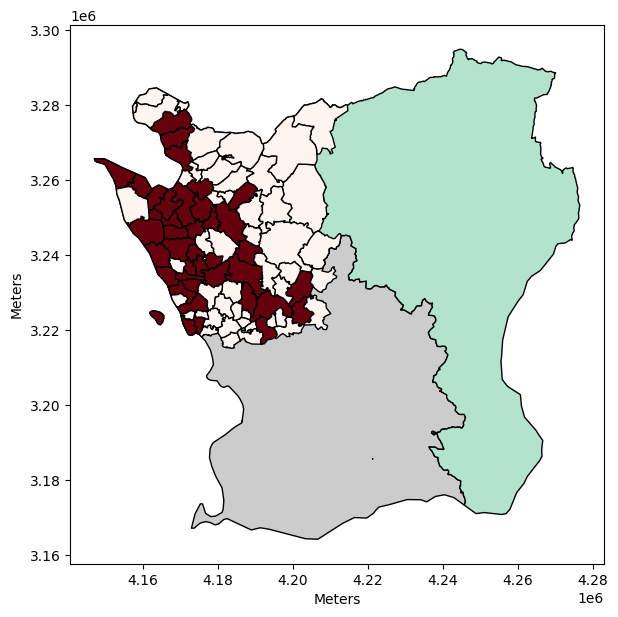

February 29, 2024 February 29, 2024